# PINNACOL CASE STUDY

## EXPLORATORY DATA ANALYSIS

```python
import pandas as pd
import numpy as np
import matplotlib.pyplot as plt
import seaborn
```

```python
df = pd.read_csv('../Data/heart-disease-cleaned.csv')
```

```python
df
```

|  | age | sex | cp | trestbps | chol | fbs | restecg | thalach | exang | oldpeak | slope | ca | thal | diagnosis |
| --- | --- | --- | --- | --- | --- | --- | --- | --- | --- | --- | --- | --- | --- | --- |
| 0 | 63.0 | 1.0 | 1.0 | 145.0 | 233.0 | 1.0 | 2.0 | 150.0 | 0.0 | 2.3 | 3.0 | 0.0 | 6.0 | 0 |
| 1 | 67.0 | 1.0 | 4.0 | 160.0 | 286.0 | 0.0 | 2.0 | 108.0 | 1.0 | 1.5 | 2.0 | 3.0 | 3.0 | 1 |
| 2 | 67.0 | 1.0 | 4.0 | 120.0 | 229.0 | 0.0 | 2.0 | 129.0 | 1.0 | 2.6 | 2.0 | 2.0 | 7.0 | 1 |
| 3 | 37.0 | 1.0 | 3.0 | 130.0 | 250.0 | 0.0 | 0.0 | 187.0 | 0.0 | 3.5 | 3.0 | 0.0 | 3.0 | 0 |
| 4 | 41.0 | 0.0 | 2.0 | 130.0 | 204.0 | 0.0 | 2.0 | 172.0 | 0.0 | 1.4 | 1.0 | 0.0 | 3.0 | 0 |
| 5 | 56.0 | 1.0 | 2.0 | 120.0 | 236.0 | 0.0 | 0.0 | 178.0 | 0.0 | 0.8 | 1.0 | 0.0 | 3.0 | 0 |
| 6 | 62.0 | 0.0 | 4.0 | 140.0 | 268.0 | 0.0 | 2.0 | 160.0 | 0.0 | 3.6 | 3.0 | 2.0 | 3.0 | 1 |
| 7 | 57.0 | 0.0 | 4.0 | 120.0 | 354.0 | 0.0 | 0.0 | 163.0 | 1.0 | 0.6 | 1.0 | 0.0 | 3.0 | 0 |
| 8 | 63.0 | 1.0 | 4.0 | 130.0 | 254.0 | 0.0 | 2.0 | 147.0 | 0.0 | 1.4 | 2.0 | 1.0 | 7.0 | 1 |
| 9 | 53.0 | 1.0 | 4.0 | 140.0 | 203.0 | 1.0 | 2.0 | 155.0 | 1.0 | 3.1 | 3.0 | 0.0 | 7.0 | 1 |
| 10 | 57.0 | 1.0 | 4.0 | 140.0 | 192.0 | 0.0 | 0.0 | 148.0 | 0.0 | 0.4 | 2.0 | 0.0 | 6.0 | 0 |
| 11 | 56.0 | 0.0 | 2.0 | 140.0 | 294.0 | 0.0 | 2.0 | 153.0 | 0.0 | 1.3 | 2.0 | 0.0 | 3.0 | 0 |
| 12 | 56.0 | 1.0 | 3.0 | 130.0 | 256.0 | 1.0 | 2.0 | 142.0 | 1.0 | 0.6 | 2.0 | 1.0 | 6.0 | 1 |
| 13 | 44.0 | 1.0 | 2.0 | 120.0 | 263.0 | 0.0 | 0.0 | 173.0 | 0.0 | 0.0 | 1.0 | 0.0 | 7.0 | 0 |
| 14 | 52.0 | 1.0 | 3.0 | 172.0 | 199.0 | 1.0 | 0.0 | 162.0 | 0.0 | 0.5 | 1.0 | 0.0 | 7.0 | 0 |
| 15 | 57.0 | 1.0 | 3.0 | 150.0 | 168.0 | 0.0 | 0.0 | 174.0 | 0.0 | 1.6 | 1.0 | 0.0 | 3.0 | 0 |
| 16 | 48.0 | 1.0 | 2.0 | 110.0 | 229.0 | 0.0 | 0.0 | 168.0 | 0.0 | 1.0 | 3.0 | 0.0 | 7.0 | 1 |
| 17 | 54.0 | 1.0 | 4.0 | 140.0 | 239.0 | 0.0 | 0.0 | 160.0 | 0.0 | 1.2 | 1.0 | 0.0 | 3.0 | 0 |
| 18 | 48.0 | 0.0 | 3.0 | 130.0 | 275.0 | 0.0 | 0.0 | 139.0 | 0.0 | 0.2 | 1.0 | 0.0 | 3.0 | 0 |
| 19 | 49.0 | 1.0 | 2.0 | 130.0 | 266.0 | 0.0 | 0.0 | 171.0 | 0.0 | 0.6 | 1.0 | 0.0 | 3.0 | 0 |
| 20 | 64.0 | 1.0 | 1.0 | 110.0 | 211.0 | 0.0 | 2.0 | 144.0 | 1.0 | 1.8 | 2.0 | 0.0 | 3.0 | 0 |
| 21 | 58.0 | 0.0 | 1.0 | 150.0 | 283.0 | 1.0 | 2.0 | 162.0 | 0.0 | 1.0 | 1.0 | 0.0 | 3.0 | 0 |
| 22 | 58.0 | 1.0 | 2.0 | 120.0 | 284.0 | 0.0 | 2.0 | 160.0 | 0.0 | 1.8 | 2.0 | 0.0 | 3.0 | 1 |
| 23 | 58.0 | 1.0 | 3.0 | 132.0 | 224.0 | 0.0 | 2.0 | 173.0 | 0.0 | 3.2 | 1.0 | 2.0 | 7.0 | 1 |
| 24 | 60.0 | 1.0 | 4.0 | 130.0 | 206.0 | 0.0 | 2.0 | 132.0 | 1.0 | 2.4 | 2.0 | 2.0 | 7.0 | 1 |
| 25 | 50.0 | 0.0 | 3.0 | 120.0 | 219.0 | 0.0 | 0.0 | 158.0 | 0.0 | 1.6 | 2.0 | 0.0 | 3.0 | 0 |
| 26 | 58.0 | 0.0 | 3.0 | 120.0 | 340.0 | 0.0 | 0.0 | 172.0 | 0.0 | 0.0 | 1.0 | 0.0 | 3.0 | 0 |
| 27 | 66.0 | 0.0 | 1.0 | 150.0 | 226.0 | 0.0 | 0.0 | 114.0 | 0.0 | 2.6 | 3.0 | 0.0 | 3.0 | 0 |
| 28 | 43.0 | 1.0 | 4.0 | 150.0 | 247.0 | 0.0 | 0.0 | 171.0 | 0.0 | 1.5 | 1.0 | 0.0 | 3.0 | 0 |
| 29 | 40.0 | 1.0 | 4.0 | 110.0 | 167.0 | 0.0 | 2.0 | 114.0 | 1.0 | 2.0 | 2.0 | 0.0 | 7.0 | 1 |
| ... | ... | ... | ... | ... | ... | ... | ... | ... | ... | ... | ... | ... | ... | ... |
| 267 | 66.0 | 1.0 | 4.0 | 160.0 | 228.0 | 0.0 | 2.0 | 138.0 | 0.0 | 2.3 | 1.0 | 0.0 | 6.0 | 0 |
| 268 | 46.0 | 1.0 | 4.0 | 140.0 | 311.0 | 0.0 | 0.0 | 120.0 | 1.0 | 1.8 | 2.0 | 2.0 | 7.0 | 1 |
| 269 | 71.0 | 0.0 | 4.0 | 112.0 | 149.0 | 0.0 | 0.0 | 125.0 | 0.0 | 1.6 | 2.0 | 0.0 | 3.0 | 0 |
| 270 | 59.0 | 1.0 | 1.0 | 134.0 | 204.0 | 0.0 | 0.0 | 162.0 | 0.0 | 0.8 | 1.0 | 2.0 | 3.0 | 1 |
| 271 | 64.0 | 1.0 | 1.0 | 170.0 | 227.0 | 0.0 | 2.0 | 155.0 | 0.0 | 0.6 | 2.0 | 0.0 | 7.0 | 0 |
| 272 | 66.0 | 0.0 | 3.0 | 146.0 | 278.0 | 0.0 | 2.0 | 152.0 | 0.0 | 0.0 | 2.0 | 1.0 | 3.0 | 0 |
| 273 | 39.0 | 0.0 | 3.0 | 138.0 | 220.0 | 0.0 | 0.0 | 152.0 | 0.0 | 0.0 | 2.0 | 0.0 | 3.0 | 0 |
| 274 | 57.0 | 1.0 | 2.0 | 154.0 | 232.0 | 0.0 | 2.0 | 164.0 | 0.0 | 0.0 | 1.0 | 1.0 | 3.0 | 1 |
| 275 | 58.0 | 0.0 | 4.0 | 130.0 | 197.0 | 0.0 | 0.0 | 131.0 | 0.0 | 0.6 | 2.0 | 0.0 | 3.0 | 0 |
| 276 | 57.0 | 1.0 | 4.0 | 110.0 | 335.0 | 0.0 | 0.0 | 143.0 | 1.0 | 3.0 | 2.0 | 1.0 | 7.0 | 1 |
| 277 | 47.0 | 1.0 | 3.0 | 130.0 | 253.0 | 0.0 | 0.0 | 179.0 | 0.0 | 0.0 | 1.0 | 0.0 | 3.0 | 0 |
| 278 | 55.0 | 0.0 | 4.0 | 128.0 | 205.0 | 0.0 | 1.0 | 130.0 | 1.0 | 2.0 | 2.0 | 1.0 | 7.0 | 1 |
| 279 | 35.0 | 1.0 | 2.0 | 122.0 | 192.0 | 0.0 | 0.0 | 174.0 | 0.0 | 0.0 | 1.0 | 0.0 | 3.0 | 0 |
| 280 | 61.0 | 1.0 | 4.0 | 148.0 | 203.0 | 0.0 | 0.0 | 161.0 | 0.0 | 0.0 | 1.0 | 1.0 | 7.0 | 1 |
| 281 | 58.0 | 1.0 | 4.0 | 114.0 | 318.0 | 0.0 | 1.0 | 140.0 | 0.0 | 4.4 | 3.0 | 3.0 | 6.0 | 1 |
| 282 | 58.0 | 0.0 | 4.0 | 170.0 | 225.0 | 1.0 | 2.0 | 146.0 | 1.0 | 2.8 | 2.0 | 2.0 | 6.0 | 1 |
| 283 | 56.0 | 1.0 | 2.0 | 130.0 | 221.0 | 0.0 | 2.0 | 163.0 | 0.0 | 0.0 | 1.0 | 0.0 | 7.0 | 0 |
| 284 | 56.0 | 1.0 | 2.0 | 120.0 | 240.0 | 0.0 | 0.0 | 169.0 | 0.0 | 0.0 | 3.0 | 0.0 | 3.0 | 0 |
| 285 | 67.0 | 1.0 | 3.0 | 152.0 | 212.0 | 0.0 | 2.0 | 150.0 | 0.0 | 0.8 | 2.0 | 0.0 | 7.0 | 1 |
| 286 | 55.0 | 0.0 | 2.0 | 132.0 | 342.0 | 0.0 | 0.0 | 166.0 | 0.0 | 1.2 | 1.0 | 0.0 | 3.0 | 0 |
| 287 | 44.0 | 1.0 | 4.0 | 120.0 | 169.0 | 0.0 | 0.0 | 144.0 | 1.0 | 2.8 | 3.0 | 0.0 | 6.0 | 1 |
| 288 | 63.0 | 1.0 | 4.0 | 140.0 | 187.0 | 0.0 | 2.0 | 144.0 | 1.0 | 4.0 | 1.0 | 2.0 | 7.0 | 1 |
| 289 | 63.0 | 0.0 | 4.0 | 124.0 | 197.0 | 0.0 | 0.0 | 136.0 | 1.0 | 0.0 | 2.0 | 0.0 | 3.0 | 1 |
| 290 | 41.0 | 1.0 | 2.0 | 120.0 | 157.0 | 0.0 | 0.0 | 182.0 | 0.0 | 0.0 | 1.0 | 0.0 | 3.0 | 0 |
| 291 | 59.0 | 1.0 | 4.0 | 164.0 | 176.0 | 1.0 | 2.0 | 90.0 | 0.0 | 1.0 | 2.0 | 2.0 | 6.0 | 1 |
| 292 | 57.0 | 0.0 | 4.0 | 140.0 | 241.0 | 0.0 | 0.0 | 123.0 | 1.0 | 0.2 | 2.0 | 0.0 | 7.0 | 1 |
| 293 | 45.0 | 1.0 | 1.0 | 110.0 | 264.0 | 0.0 | 0.0 | 132.0 | 0.0 | 1.2 | 2.0 | 0.0 | 7.0 | 1 |
| 294 | 68.0 | 1.0 | 4.0 | 144.0 | 193.0 | 1.0 | 0.0 | 141.0 | 0.0 | 3.4 | 2.0 | 2.0 | 7.0 | 1 |
| 295 | 57.0 | 1.0 | 4.0 | 130.0 | 131.0 | 0.0 | 0.0 | 115.0 | 1.0 | 1.2 | 2.0 | 1.0 | 7.0 | 1 |
| 296 | 57.0 | 0.0 | 2.0 | 130.0 | 236.0 | 0.0 | 2.0 | 174.0 | 0.0 | 0.0 | 2.0 | 1.0 | 3.0 | 1 |

297 rows × 14 columns

```python
from eda import get_box
box_cols = ['age', 'trestbps', 'chol', 'thalach', 'oldpeak']
df_yes = df[df['diagnosis'] == 1]
df_no = df[df['diagnosis'] == 0]
```

## AGE

### All Instances:

```python
df.age.describe()
```

```
count    297.000000
mean      54.542088
std        9.049736
min       29.000000
25%       48.000000
50%       56.000000
75%       61.000000
max       77.000000
Name: age, dtype: float64
```

### Positive diagnosis:

```python
df_yes.age.describe()
```

```
count    137.000000
mean      56.759124
std        7.899670
min       35.000000
25%       53.000000
50%       58.000000
75%       62.000000
max       77.000000
Name: age, dtype: float64
```

### Negative Diagnosis:

```python
df_no.age.describe()
```

```
count    160.000000
mean      52.643750
std        9.551151
min       29.000000
25%       44.750000
50%       52.000000
75%       59.000000
max       76.000000
Name: age, dtype: float64
```

#### The mean age for those diagnosed with heart disease is higher than those not diagnosed with heart disease

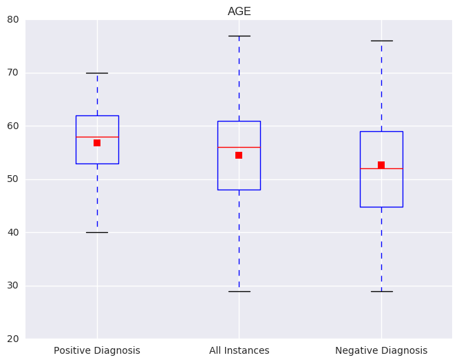

```python
get_box(df, 'age')
```

## SERUM CHOLESTORAL

### All Instances

```python
df.chol.describe()
```

```
count    297.000000
mean     247.350168
std       51.997583
min      126.000000
25%      211.000000
50%      243.000000
75%      276.000000
max      564.000000
Name: chol, dtype: float64
```

### Positive Diagnosis

```python
df_yes.chol.describe()
```

```
count    137.000000
mean     251.854015
std       49.679937
min      131.000000
25%      218.000000
50%      253.000000
75%      284.000000
max      409.000000
Name: chol, dtype: float64
```

### Negative Diagnosis

```python
df_no.chol.describe()
```

```
count    160.00000
mean     243.49375
std       53.75755
min      126.00000
25%      208.75000
50%      235.50000
75%      268.25000
max      564.00000
Name: chol, dtype: float64
```

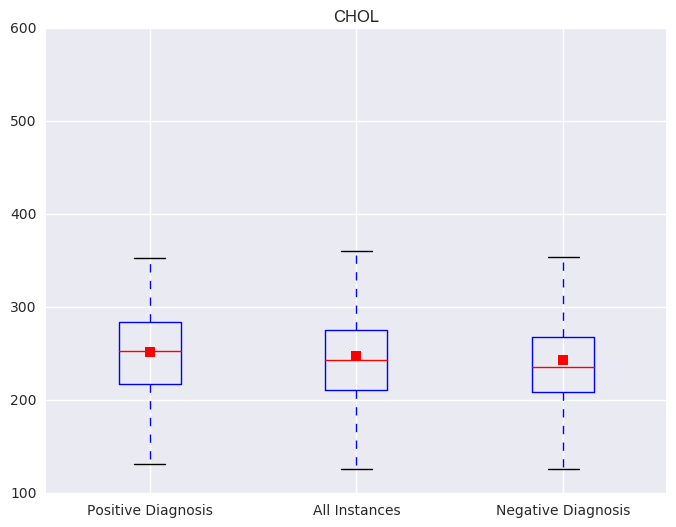

```python
get_box(df, 'chol')
```

## MAXIMUM HEART RATE ACHIEVED

### All instances

```python
df.thalach.describe()
```

```
count    297.000000
mean     149.599327
std       22.941562
min       71.000000
25%      133.000000
50%      153.000000
75%      166.000000
max      202.000000
Name: thalach, dtype: float64
```

### Positive Diagnosis

```python
df_yes.thalach.describe()
```

```
count    137.000000
mean     139.109489
std       22.710673
min       71.000000
25%      125.000000
50%      142.000000
75%      157.000000
max      195.000000
Name: thalach, dtype: float64
```

### Negative Diagnosis

```python
df_no.thalach.describe()
```

```
count    160.000000
mean     158.581250
std       19.043304
min       96.000000
25%      149.000000
50%      161.000000
75%      172.000000
max      202.000000
Name: thalach, dtype: float64
```

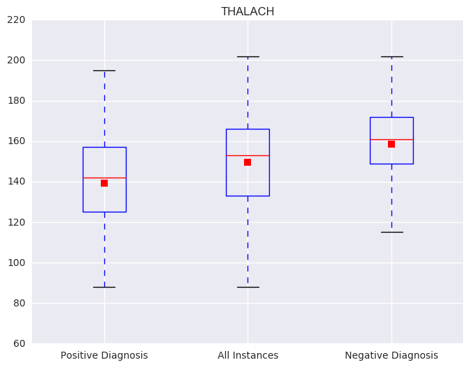

```python
get_box(df, 'thalach')
```

## ST DEPRESSION INDUCED BY EXERCISE RELATIVE TO REST

### All Instances:

```python
df.oldpeak.describe()
```

```
count    297.000000
mean       1.055556
std        1.166123
min        0.000000
25%        0.000000
50%        0.800000
75%        1.600000
max        6.200000
Name: oldpeak, dtype: float64
```

### Positive Diagnosis

```python
df_yes.oldpeak.describe()
```

```
count    137.000000
mean       1.589051
std        1.305006
min        0.000000
25%        0.600000
50%        1.400000
75%        2.500000
max        6.200000
Name: oldpeak, dtype: float64
```

### Negative Diagnosis

```python
df_no.oldpeak.describe()
```

```
count    160.00000
mean       0.59875
std        0.78716
min        0.00000
25%        0.00000
50%        0.20000
75%        1.10000
max        4.20000
Name: oldpeak, dtype: float64
```

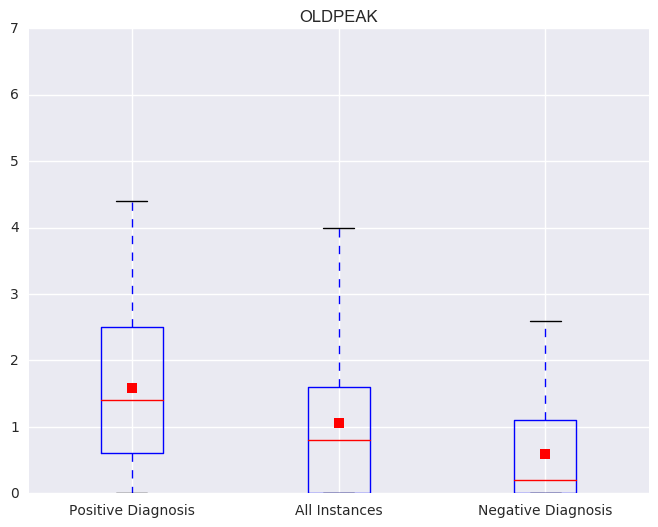

```python
get_box(df, 'oldpeak')
```

```python
from eda import get_bars
bar_cols = ['sex', 'cp', 'fbs', 'restecg', 'exang', 'slope', 'ca', 'thal']
def get_true_values(df):
    df['sex'] = df.sex.map({1: 'Male', 0: 'Female'})
    df['cp'] = df.cp.map({1: 'Typical angina',
                            2: 'Atypical angina',
                            3: 'Non-anginal pain',
                            4: 'Asymptomatic'})
    df['fbs'] = df.fbs.map({1: '> 120 mg/dl', 0: '< 120 mg/dl'})
    df['restecg'] = df.restecg.map({0: 'Normal',
                                    1: 'ST-T wave abnormality',
                                    2: 'Left Ventrical Hypertrophy'})
    df['exang'] = df.exang.map({1: 'Yes', 0: 'No'})
    df['slope'] = df.slope.map({1: 'Upsloping',
                                2: 'Flat',
                                3: 'Downsloping'})
    df['thal'] = df.thal.map({3: 'Normal',
                                6: 'Fixed Defect',
                                7 : 'Reversable Defect'})
    return df
```

```python
cat_df = get_true_values(df)
cat_df_yes = cat_df[cat_df['diagnosis'] == 1]
cat_df_no = cat_df[cat_df['diagnosis'] == 0]
cat_df
```

|  | age | sex | cp | trestbps | chol | fbs | restecg | thalach | exang | oldpeak | slope | ca | thal | diagnosis |
| --- | --- | --- | --- | --- | --- | --- | --- | --- | --- | --- | --- | --- | --- | --- |
| 0 | 63.0 | Male | Typical angina | 145.0 | 233.0 | > 120 mg/dl | Left Ventrical Hypertrophy | 150.0 | No | 2.3 | Downsloping | 0.0 | Fixed Defect | 0 |
| 1 | 67.0 | Male | Asymptomatic | 160.0 | 286.0 | < 120 mg/dl | Left Ventrical Hypertrophy | 108.0 | Yes | 1.5 | Flat | 3.0 | Normal | 1 |
| 2 | 67.0 | Male | Asymptomatic | 120.0 | 229.0 | < 120 mg/dl | Left Ventrical Hypertrophy | 129.0 | Yes | 2.6 | Flat | 2.0 | Reversable Defect | 1 |
| 3 | 37.0 | Male | Non-anginal pain | 130.0 | 250.0 | < 120 mg/dl | Normal | 187.0 | No | 3.5 | Downsloping | 0.0 | Normal | 0 |
| 4 | 41.0 | Female | Atypical angina | 130.0 | 204.0 | < 120 mg/dl | Left Ventrical Hypertrophy | 172.0 | No | 1.4 | Upsloping | 0.0 | Normal | 0 |
| 5 | 56.0 | Male | Atypical angina | 120.0 | 236.0 | < 120 mg/dl | Normal | 178.0 | No | 0.8 | Upsloping | 0.0 | Normal | 0 |
| 6 | 62.0 | Female | Asymptomatic | 140.0 | 268.0 | < 120 mg/dl | Left Ventrical Hypertrophy | 160.0 | No | 3.6 | Downsloping | 2.0 | Normal | 1 |
| 7 | 57.0 | Female | Asymptomatic | 120.0 | 354.0 | < 120 mg/dl | Normal | 163.0 | Yes | 0.6 | Upsloping | 0.0 | Normal | 0 |
| 8 | 63.0 | Male | Asymptomatic | 130.0 | 254.0 | < 120 mg/dl | Left Ventrical Hypertrophy | 147.0 | No | 1.4 | Flat | 1.0 | Reversable Defect | 1 |
| 9 | 53.0 | Male | Asymptomatic | 140.0 | 203.0 | > 120 mg/dl | Left Ventrical Hypertrophy | 155.0 | Yes | 3.1 | Downsloping | 0.0 | Reversable Defect | 1 |
| 10 | 57.0 | Male | Asymptomatic | 140.0 | 192.0 | < 120 mg/dl | Normal | 148.0 | No | 0.4 | Flat | 0.0 | Fixed Defect | 0 |
| 11 | 56.0 | Female | Atypical angina | 140.0 | 294.0 | < 120 mg/dl | Left Ventrical Hypertrophy | 153.0 | No | 1.3 | Flat | 0.0 | Normal | 0 |
| 12 | 56.0 | Male | Non-anginal pain | 130.0 | 256.0 | > 120 mg/dl | Left Ventrical Hypertrophy | 142.0 | Yes | 0.6 | Flat | 1.0 | Fixed Defect | 1 |
| 13 | 44.0 | Male | Atypical angina | 120.0 | 263.0 | < 120 mg/dl | Normal | 173.0 | No | 0.0 | Upsloping | 0.0 | Reversable Defect | 0 |
| 14 | 52.0 | Male | Non-anginal pain | 172.0 | 199.0 | > 120 mg/dl | Normal | 162.0 | No | 0.5 | Upsloping | 0.0 | Reversable Defect | 0 |
| 15 | 57.0 | Male | Non-anginal pain | 150.0 | 168.0 | < 120 mg/dl | Normal | 174.0 | No | 1.6 | Upsloping | 0.0 | Normal | 0 |
| 16 | 48.0 | Male | Atypical angina | 110.0 | 229.0 | < 120 mg/dl | Normal | 168.0 | No | 1.0 | Downsloping | 0.0 | Reversable Defect | 1 |
| 17 | 54.0 | Male | Asymptomatic | 140.0 | 239.0 | < 120 mg/dl | Normal | 160.0 | No | 1.2 | Upsloping | 0.0 | Normal | 0 |
| 18 | 48.0 | Female | Non-anginal pain | 130.0 | 275.0 | < 120 mg/dl | Normal | 139.0 | No | 0.2 | Upsloping | 0.0 | Normal | 0 |
| 19 | 49.0 | Male | Atypical angina | 130.0 | 266.0 | < 120 mg/dl | Normal | 171.0 | No | 0.6 | Upsloping | 0.0 | Normal | 0 |
| 20 | 64.0 | Male | Typical angina | 110.0 | 211.0 | < 120 mg/dl | Left Ventrical Hypertrophy | 144.0 | Yes | 1.8 | Flat | 0.0 | Normal | 0 |
| 21 | 58.0 | Female | Typical angina | 150.0 | 283.0 | > 120 mg/dl | Left Ventrical Hypertrophy | 162.0 | No | 1.0 | Upsloping | 0.0 | Normal | 0 |
| 22 | 58.0 | Male | Atypical angina | 120.0 | 284.0 | < 120 mg/dl | Left Ventrical Hypertrophy | 160.0 | No | 1.8 | Flat | 0.0 | Normal | 1 |
| 23 | 58.0 | Male | Non-anginal pain | 132.0 | 224.0 | < 120 mg/dl | Left Ventrical Hypertrophy | 173.0 | No | 3.2 | Upsloping | 2.0 | Reversable Defect | 1 |
| 24 | 60.0 | Male | Asymptomatic | 130.0 | 206.0 | < 120 mg/dl | Left Ventrical Hypertrophy | 132.0 | Yes | 2.4 | Flat | 2.0 | Reversable Defect | 1 |
| 25 | 50.0 | Female | Non-anginal pain | 120.0 | 219.0 | < 120 mg/dl | Normal | 158.0 | No | 1.6 | Flat | 0.0 | Normal | 0 |
| 26 | 58.0 | Female | Non-anginal pain | 120.0 | 340.0 | < 120 mg/dl | Normal | 172.0 | No | 0.0 | Upsloping | 0.0 | Normal | 0 |
| 27 | 66.0 | Female | Typical angina | 150.0 | 226.0 | < 120 mg/dl | Normal | 114.0 | No | 2.6 | Downsloping | 0.0 | Normal | 0 |
| 28 | 43.0 | Male | Asymptomatic | 150.0 | 247.0 | < 120 mg/dl | Normal | 171.0 | No | 1.5 | Upsloping | 0.0 | Normal | 0 |
| 29 | 40.0 | Male | Asymptomatic | 110.0 | 167.0 | < 120 mg/dl | Left Ventrical Hypertrophy | 114.0 | Yes | 2.0 | Flat | 0.0 | Reversable Defect | 1 |
| ... | ... | ... | ... | ... | ... | ... | ... | ... | ... | ... | ... | ... | ... | ... |
| 267 | 66.0 | Male | Asymptomatic | 160.0 | 228.0 | < 120 mg/dl | Left Ventrical Hypertrophy | 138.0 | No | 2.3 | Upsloping | 0.0 | Fixed Defect | 0 |
| 268 | 46.0 | Male | Asymptomatic | 140.0 | 311.0 | < 120 mg/dl | Normal | 120.0 | Yes | 1.8 | Flat | 2.0 | Reversable Defect | 1 |
| 269 | 71.0 | Female | Asymptomatic | 112.0 | 149.0 | < 120 mg/dl | Normal | 125.0 | No | 1.6 | Flat | 0.0 | Normal | 0 |
| 270 | 59.0 | Male | Typical angina | 134.0 | 204.0 | < 120 mg/dl | Normal | 162.0 | No | 0.8 | Upsloping | 2.0 | Normal | 1 |
| 271 | 64.0 | Male | Typical angina | 170.0 | 227.0 | < 120 mg/dl | Left Ventrical Hypertrophy | 155.0 | No | 0.6 | Flat | 0.0 | Reversable Defect | 0 |
| 272 | 66.0 | Female | Non-anginal pain | 146.0 | 278.0 | < 120 mg/dl | Left Ventrical Hypertrophy | 152.0 | No | 0.0 | Flat | 1.0 | Normal | 0 |
| 273 | 39.0 | Female | Non-anginal pain | 138.0 | 220.0 | < 120 mg/dl | Normal | 152.0 | No | 0.0 | Flat | 0.0 | Normal | 0 |
| 274 | 57.0 | Male | Atypical angina | 154.0 | 232.0 | < 120 mg/dl | Left Ventrical Hypertrophy | 164.0 | No | 0.0 | Upsloping | 1.0 | Normal | 1 |
| 275 | 58.0 | Female | Asymptomatic | 130.0 | 197.0 | < 120 mg/dl | Normal | 131.0 | No | 0.6 | Flat | 0.0 | Normal | 0 |
| 276 | 57.0 | Male | Asymptomatic | 110.0 | 335.0 | < 120 mg/dl | Normal | 143.0 | Yes | 3.0 | Flat | 1.0 | Reversable Defect | 1 |
| 277 | 47.0 | Male | Non-anginal pain | 130.0 | 253.0 | < 120 mg/dl | Normal | 179.0 | No | 0.0 | Upsloping | 0.0 | Normal | 0 |
| 278 | 55.0 | Female | Asymptomatic | 128.0 | 205.0 | < 120 mg/dl | ST-T wave abnormality | 130.0 | Yes | 2.0 | Flat | 1.0 | Reversable Defect | 1 |
| 279 | 35.0 | Male | Atypical angina | 122.0 | 192.0 | < 120 mg/dl | Normal | 174.0 | No | 0.0 | Upsloping | 0.0 | Normal | 0 |
| 280 | 61.0 | Male | Asymptomatic | 148.0 | 203.0 | < 120 mg/dl | Normal | 161.0 | No | 0.0 | Upsloping | 1.0 | Reversable Defect | 1 |
| 281 | 58.0 | Male | Asymptomatic | 114.0 | 318.0 | < 120 mg/dl | ST-T wave abnormality | 140.0 | No | 4.4 | Downsloping | 3.0 | Fixed Defect | 1 |
| 282 | 58.0 | Female | Asymptomatic | 170.0 | 225.0 | > 120 mg/dl | Left Ventrical Hypertrophy | 146.0 | Yes | 2.8 | Flat | 2.0 | Fixed Defect | 1 |
| 283 | 56.0 | Male | Atypical angina | 130.0 | 221.0 | < 120 mg/dl | Left Ventrical Hypertrophy | 163.0 | No | 0.0 | Upsloping | 0.0 | Reversable Defect | 0 |
| 284 | 56.0 | Male | Atypical angina | 120.0 | 240.0 | < 120 mg/dl | Normal | 169.0 | No | 0.0 | Downsloping | 0.0 | Normal | 0 |
| 285 | 67.0 | Male | Non-anginal pain | 152.0 | 212.0 | < 120 mg/dl | Left Ventrical Hypertrophy | 150.0 | No | 0.8 | Flat | 0.0 | Reversable Defect | 1 |
| 286 | 55.0 | Female | Atypical angina | 132.0 | 342.0 | < 120 mg/dl | Normal | 166.0 | No | 1.2 | Upsloping | 0.0 | Normal | 0 |
| 287 | 44.0 | Male | Asymptomatic | 120.0 | 169.0 | < 120 mg/dl | Normal | 144.0 | Yes | 2.8 | Downsloping | 0.0 | Fixed Defect | 1 |
| 288 | 63.0 | Male | Asymptomatic | 140.0 | 187.0 | < 120 mg/dl | Left Ventrical Hypertrophy | 144.0 | Yes | 4.0 | Upsloping | 2.0 | Reversable Defect | 1 |
| 289 | 63.0 | Female | Asymptomatic | 124.0 | 197.0 | < 120 mg/dl | Normal | 136.0 | Yes | 0.0 | Flat | 0.0 | Normal | 1 |
| 290 | 41.0 | Male | Atypical angina | 120.0 | 157.0 | < 120 mg/dl | Normal | 182.0 | No | 0.0 | Upsloping | 0.0 | Normal | 0 |
| 291 | 59.0 | Male | Asymptomatic | 164.0 | 176.0 | > 120 mg/dl | Left Ventrical Hypertrophy | 90.0 | No | 1.0 | Flat | 2.0 | Fixed Defect | 1 |
| 292 | 57.0 | Female | Asymptomatic | 140.0 | 241.0 | < 120 mg/dl | Normal | 123.0 | Yes | 0.2 | Flat | 0.0 | Reversable Defect | 1 |
| 293 | 45.0 | Male | Typical angina | 110.0 | 264.0 | < 120 mg/dl | Normal | 132.0 | No | 1.2 | Flat | 0.0 | Reversable Defect | 1 |
| 294 | 68.0 | Male | Asymptomatic | 144.0 | 193.0 | > 120 mg/dl | Normal | 141.0 | No | 3.4 | Flat | 2.0 | Reversable Defect | 1 |
| 295 | 57.0 | Male | Asymptomatic | 130.0 | 131.0 | < 120 mg/dl | Normal | 115.0 | Yes | 1.2 | Flat | 1.0 | Reversable Defect | 1 |
| 296 | 57.0 | Female | Atypical angina | 130.0 | 236.0 | < 120 mg/dl | Left Ventrical Hypertrophy | 174.0 | No | 0.0 | Flat | 1.0 | Normal | 1 |

297 rows × 14 columns

## GENDER

### THE OVERWHELMING MAJORITY OF POSITIVE DIAGNOSES WERE MALES

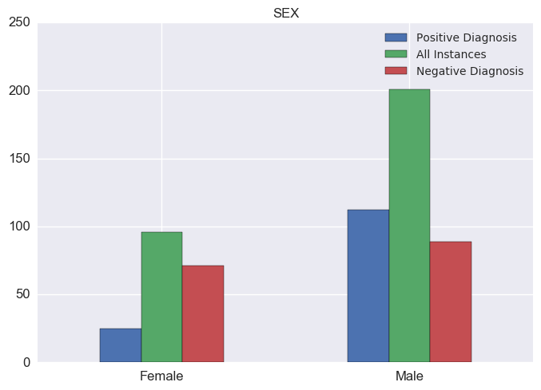

```python
get_bars(cat_df, 'sex')
```

#### Value counts for positive diagnoses

```python
cat_df_yes.sex.value_counts()
```

```
Male      112
Female     25
Name: sex, dtype: int64
```

```python
cat_df_f = cat_df[cat_df['sex'] == 'Female']
cat_df_m = cat_df[cat_df['sex'] == 'Male']
```

### 26% of women were diagnosed with heart disease while 55.7% of men received a positive diagnosis

```python
cat_df_f.diagnosis.mean()
```

```
0.2604166666666667
```

```python
cat_df_m.diagnosis.mean()
```

```
0.5572139303482587
```

## CHEST PAIN

### INTERESTINGLY ENOUGH, MORE POSITIVE DIAGNOSES WERE GIVEN TO THOSE WITH ASYMPTOMATIC CHEST PAIN THEN ANY OTHER TYPE OF CHEST PAIN

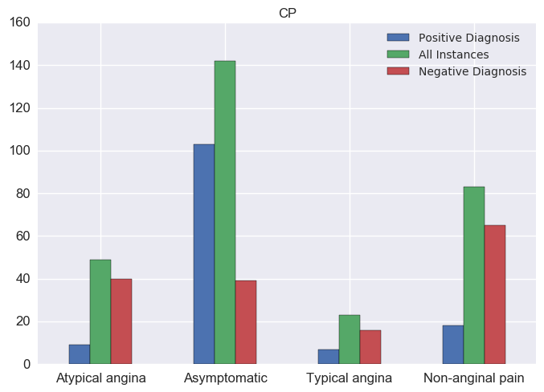

```python
get_bars(cat_df, 'cp')
```

### Value counts for chest pain for all instances

```python
cat_df.cp.value_counts()
```

```
Asymptomatic        142
Non-anginal pain     83
Atypical angina      49
Typical angina       23
Name: cp, dtype: int64
```

### Value counts for chest pain for positive diagnoses

```python
cat_df_yes.cp.value_counts()
```

```
Asymptomatic        103
Non-anginal pain     18
Atypical angina       9
Typical angina        7
Name: cp, dtype: int64
```

### 75% of positive diagnoses reported having asymptomatic chest pain

```python
float(cat_df_yes.cp.describe()['freq'])/cat_df_yes.cp.describe()['count']
```

```
0.7518248175182481
```

## FASTING BLOOD SUGAR

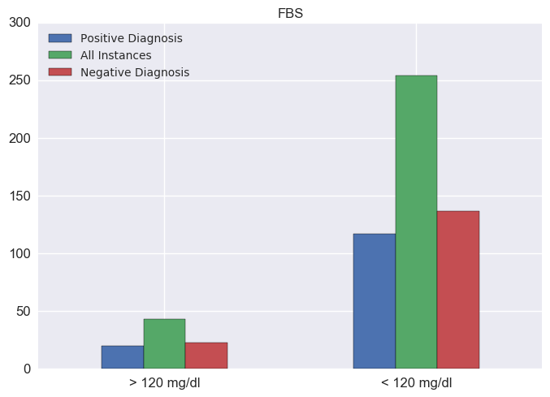

```python
get_bars(cat_df, 'fbs')
```

### Value counts for positive diagnosis

```python
cat_df_yes.fbs.value_counts()
```

```
< 120 mg/dl    117
> 120 mg/dl     20
Name: fbs, dtype: int64
```

### Value counts for negative diagnosis

```python
cat_df_no.fbs.value_counts()
```

```
< 120 mg/dl    137
> 120 mg/dl     23
Name: fbs, dtype: int64
```

```python
cat_df_yes.fbs.describe()
```

```
count             137
unique              2
top       < 120 mg/dl
freq              117
Name: fbs, dtype: object
```

### 85% of patients with fbs < 120 mg/dl were both positively and negatively diagnosed

```python
float(cat_df_yes.fbs.describe()['freq'])/cat_df_yes.fbs.describe()['count']
```

```
0.8540145985401459
```

```python
float(cat_df_no.fbs.describe()['freq'])/cat_df_no.fbs.describe()['count']
```

```
0.85625
```

## RESTING ELECTROCARDIOGRAPHIC RESULTS

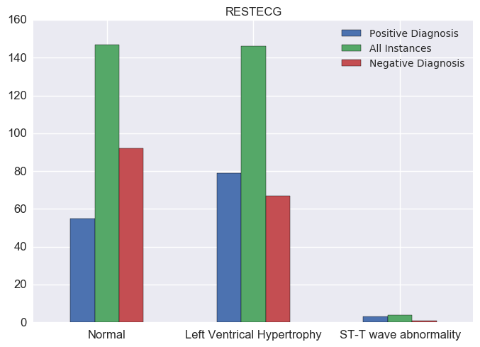

```python
get_bars(cat_df, 'restecg')
```

### Value counts for all instances

```python
cat_df.restecg.value_counts()
```

```
Normal                        147
Left Ventrical Hypertrophy    146
ST-T wave abnormality           4
Name: restecg, dtype: int64
```

### Value counts for positive diagnosis

```python
cat_df_yes.restecg.value_counts()
```

```
Left Ventrical Hypertrophy    79
Normal                        55
ST-T wave abnormality          3
Name: restecg, dtype: int64
```

```python
cat_df_yes.restecg.describe()
```

```
count                            137
unique                             3
top       Left Ventrical Hypertrophy
freq                              79
Name: restecg, dtype: object
```

### 57.6% of positive diagnosed patients had Left Ventrical Hypertrophy

```python
float(cat_df_yes.restecg.describe()['freq'])/cat_df_yes.restecg.describe()['count']
```

```
0.5766423357664233
```

```python
cat_df_no.restecg.describe()
```

```
count        160
unique         3
top       Normal
freq          92
Name: restecg, dtype: object
```

```python
df_lvh = cat_df[cat_df['restecg'] == 'Left Ventrical Hypertrophy']
df_norm = cat_df[cat_df['restecg'] == 'Normal']
```

### 54% of patients with Left Ventrical Hypertrophy were diagnosed with heart disease

```python
df_lvh.diagnosis.value_counts()/df_lvh.diagnosis.value_counts().sum()
```

```
1    0.541096
0    0.458904
Name: diagnosis, dtype: float64
```

### 37% of patients with Normal RestECG were diagnosed with heart disease

```python
df_norm.diagnosis.value_counts()/df_norm.diagnosis.value_counts().sum()
```

```
0    0.62585
1    0.37415
Name: diagnosis, dtype: float64
```

## EXERCISE INDUCED ANGINA

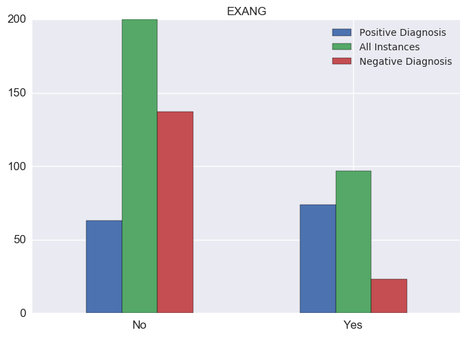

```python
get_bars(cat_df, 'exang')
```

```python
df_exang_yes = cat_df[cat_df['exang'] == 'Yes']
```

### 76.2% of patients with Exercise Induced Angina were diagnosed with heart disease

```python
df_exang_yes.diagnosis.value_counts()/df_exang_yes.diagnosis.value_counts().sum()
```

```
1    0.762887
0    0.237113
Name: diagnosis, dtype: float64
```

## SLOPE OF PEAK EXERCISE ST SEGMENT

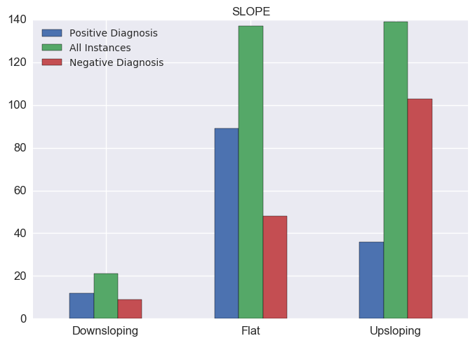

```python
get_bars(cat_df, 'slope')
```

## VESSELS COLORED BY FLOUROSCOPY

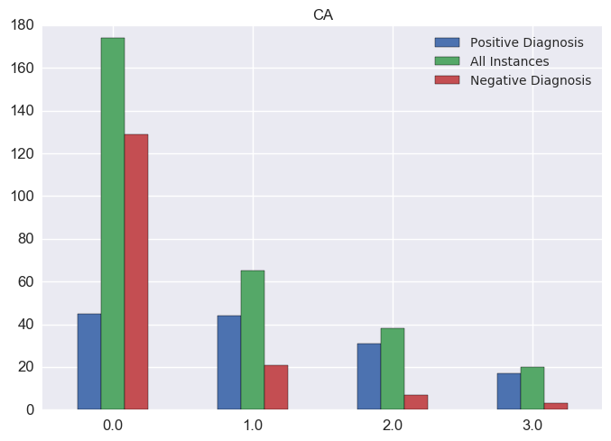

```python
get_bars(cat_df, 'ca')
```

### More coloring resulted in a higher proportion of diagnosed patients

#### This shows the proportion of patients diagnosed with heart disease compared to the number of vessels found the have coloring

```python
cat_df_yes.ca.value_counts()/cat_df.ca.value_counts()
```

```
0.0    0.258621
1.0    0.676923
2.0    0.815789
3.0    0.850000
Name: ca, dtype: float64
```

## THALIUM SCAN

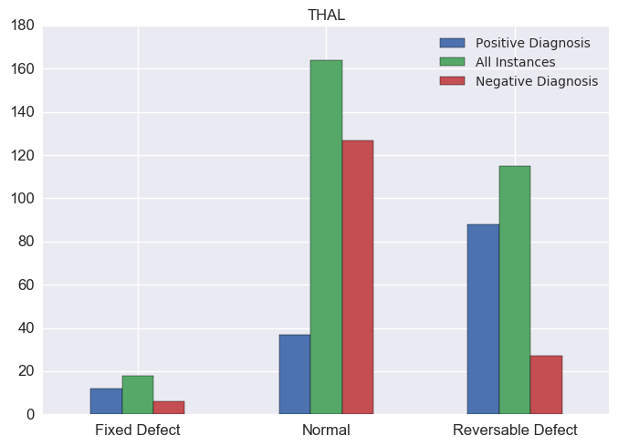

```python
get_bars(cat_df, 'thal')
```

### 64% of patients diagnosed with heart disease had a Reversable Defect

```python
float(cat_df_yes.thal.describe()['freq'])/cat_df_yes.thal.describe()['count']
```

```
0.6423357664233577
```

```python
new_df = pd.read_csv('../Data/heart-disease-cleaned.csv')
```

```python
new_df.corr()
```

|  | age | sex | cp | trestbps | chol | fbs | restecg | thalach | exang | oldpeak | slope | ca | thal | diagnosis |
| --- | --- | --- | --- | --- | --- | --- | --- | --- | --- | --- | --- | --- | --- | --- |
| age | 1.000000 | -0.092399 | 0.110471 | 0.290476 | 0.202644 | 0.132062 | 0.149917 | -0.394563 | 0.096489 | 0.197123 | 0.159405 | 0.362210 | 0.126586 | 0.227075 |
| sex | -0.092399 | 1.000000 | 0.008908 | -0.066340 | -0.198089 | 0.038850 | 0.033897 | -0.060496 | 0.143581 | 0.106567 | 0.033345 | 0.091925 | 0.383652 | 0.278467 |
| cp | 0.110471 | 0.008908 | 1.000000 | -0.036980 | 0.072088 | -0.057663 | 0.063905 | -0.339308 | 0.377525 | 0.203244 | 0.151079 | 0.235644 | 0.268500 | 0.408945 |
| trestbps | 0.290476 | -0.066340 | -0.036980 | 1.000000 | 0.131536 | 0.180860 | 0.149242 | -0.049108 | 0.066691 | 0.191243 | 0.121172 | 0.097954 | 0.138183 | 0.153490 |
| chol | 0.202644 | -0.198089 | 0.072088 | 0.131536 | 1.000000 | 0.012708 | 0.165046 | -0.000075 | 0.059339 | 0.038596 | -0.009215 | 0.115945 | 0.010859 | 0.080285 |
| fbs | 0.132062 | 0.038850 | -0.057663 | 0.180860 | 0.012708 | 1.000000 | 0.068831 | -0.007842 | -0.000893 | 0.008311 | 0.047819 | 0.152086 | 0.062209 | 0.003167 |
| restecg | 0.149917 | 0.033897 | 0.063905 | 0.149242 | 0.165046 | 0.068831 | 1.000000 | -0.072290 | 0.081874 | 0.113726 | 0.135141 | 0.129021 | 0.018795 | 0.166343 |
| thalach | -0.394563 | -0.060496 | -0.339308 | -0.049108 | -0.000075 | -0.007842 | -0.072290 | 1.000000 | -0.384368 | -0.347640 | -0.389307 | -0.268727 | -0.274831 | -0.423817 |
| exang | 0.096489 | 0.143581 | 0.377525 | 0.066691 | 0.059339 | -0.000893 | 0.081874 | -0.384368 | 1.000000 | 0.289310 | 0.250572 | 0.148232 | 0.326927 | 0.421355 |
| oldpeak | 0.197123 | 0.106567 | 0.203244 | 0.191243 | 0.038596 | 0.008311 | 0.113726 | -0.347640 | 0.289310 | 1.000000 | 0.579037 | 0.294452 | 0.344976 | 0.424052 |
| slope | 0.159405 | 0.033345 | 0.151079 | 0.121172 | -0.009215 | 0.047819 | 0.135141 | -0.389307 | 0.250572 | 0.579037 | 1.000000 | 0.109761 | 0.279688 | 0.333049 |
| ca | 0.362210 | 0.091925 | 0.235644 | 0.097954 | 0.115945 | 0.152086 | 0.129021 | -0.268727 | 0.148232 | 0.294452 | 0.109761 | 1.000000 | 0.256382 | 0.463189 |
| thal | 0.126586 | 0.383652 | 0.268500 | 0.138183 | 0.010859 | 0.062209 | 0.018795 | -0.274831 | 0.326927 | 0.344976 | 0.279688 | 0.256382 | 1.000000 | 0.526640 |
| diagnosis | 0.227075 | 0.278467 | 0.408945 | 0.153490 | 0.080285 | 0.003167 | 0.166343 | -0.423817 | 0.421355 | 0.424052 | 0.333049 | 0.463189 | 0.526640 | 1.000000 |

## This is easier to see here

```python
new_df.corr()[new_df.corr() > 0.4].fillna('')
```

|  | age | sex | cp | trestbps | chol | fbs | restecg | thalach | exang | oldpeak | slope | ca | thal | diagnosis |
| --- | --- | --- | --- | --- | --- | --- | --- | --- | --- | --- | --- | --- | --- | --- |
| age | 1 |  |  |  |  |  |  |  |  |  |  |  |  |  |
| sex |  | 1 |  |  |  |  |  |  |  |  |  |  |  |  |
| cp |  |  | 1 |  |  |  |  |  |  |  |  |  |  | 0.408945 |
| trestbps |  |  |  | 1 |  |  |  |  |  |  |  |  |  |  |
| chol |  |  |  |  | 1 |  |  |  |  |  |  |  |  |  |
| fbs |  |  |  |  |  | 1 |  |  |  |  |  |  |  |  |
| restecg |  |  |  |  |  |  | 1 |  |  |  |  |  |  |  |
| thalach |  |  |  |  |  |  |  | 1 |  |  |  |  |  |  |
| exang |  |  |  |  |  |  |  |  | 1 |  |  |  |  | 0.421355 |
| oldpeak |  |  |  |  |  |  |  |  |  | 1 | 0.579037 |  |  | 0.424052 |
| slope |  |  |  |  |  |  |  |  |  | 0.579037 | 1 |  |  |  |
| ca |  |  |  |  |  |  |  |  |  |  |  | 1 |  | 0.463189 |
| thal |  |  |  |  |  |  |  |  |  |  |  |  | 1 | 0.52664 |
| diagnosis |  |  | 0.408945 |  |  |  |  |  | 0.421355 | 0.424052 |  | 0.463189 | 0.52664 | 1 |